## Ex-01.2-anorexia

Paul Johnson, CRMDA <pauljohn@ku.edu>

Feb. 8 2018

Abstract

RHS anorexia exercise

# Data import

```r
library(foreign)
dat <- read.dta("anorexia.dta12")
rockchalk::summarize(dat)
```

```
## Numeric variables
##            weight1   weight2
## min         70        71.30
## med         82.30     84.05
## max         94.90    103.60
## mean        82.41     85.17
## sd           5.18      8.04
## skewness    -0.05      0.36
## kurtosis    -0.16     -0.81
## nobs        72        72
## nmissing     0         0
##
## Nonnumeric variables
##     treat
##  cbt   : 29
##  contrl: 26
##  ft    : 17
##  nobs  : 72
##  nmiss :  0
##  entropy      : 1.55
##  normedEntropy: 0.98
```

# Descriptive Statistics

Obtain summary statistics for each treatment group. The tidyverse loving Jake and Jihong say dplyr to rescue:

```r
library(dplyr)
t0.dplyr <- dat %>%
    group_by(treat) %>%
    summarize(N = n(), Preweight = mean(weight1, na.rm = TRUE),
              Postweight = mean(weight2, na.rm = TRUE))
t0.dplyr
```

```
## # A tibble: 3 x 4
##    treat     N Preweight Postweight
##   <fctr> <int>     <dbl>      <dbl>
## 1    cbt    29  82.68966   85.69655
## 2 contrl    26  81.55769   81.10769
## 3     ft    17  83.22941   90.49412
```

I don’t enjoy using dplyr and I dislike %>%, so I’d use aggregate() or an lapply-based approach.

```r
t1 <- aggregate(dat[, c("weight1", "weight2")],
                by = list(treat = dat$treat), mean, na.rm = TRUE)
t1[ , "N"] <- table(dat$treat)
t1
```

```
##    treat  weight1  weight2  N
## 1    cbt 82.68966 85.69655 29
## 2 contrl 81.55769 81.10769 26
## 3     ft 83.22941 90.49412 17
```

```r
t2 <- lapply(split(dat, f = dat$treat),
       function(x){
           data.frame(treat = unique(x$treat),
             N = NROW(x),
             weight1 = mean(x$weight1, na.rm = TRUE),
             weight2 = mean(x$weight2, na.rm = TRUE))
       }
)
do.call("rbind", t2)
```

```
##         treat  N  weight1  weight2
## cbt       cbt 29 82.68966 85.69655
## contrl contrl 26 81.55769 81.10769
## ft         ft 17 83.22941 90.49412
```

Exploratory data descriptions with histogram and boxplot

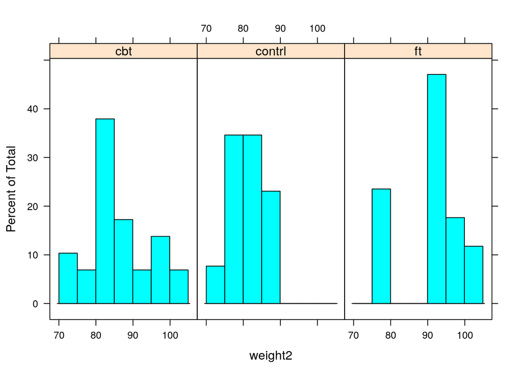

```r
library(lattice)
histogram( ~ weight2 | treat, data = dat)
```

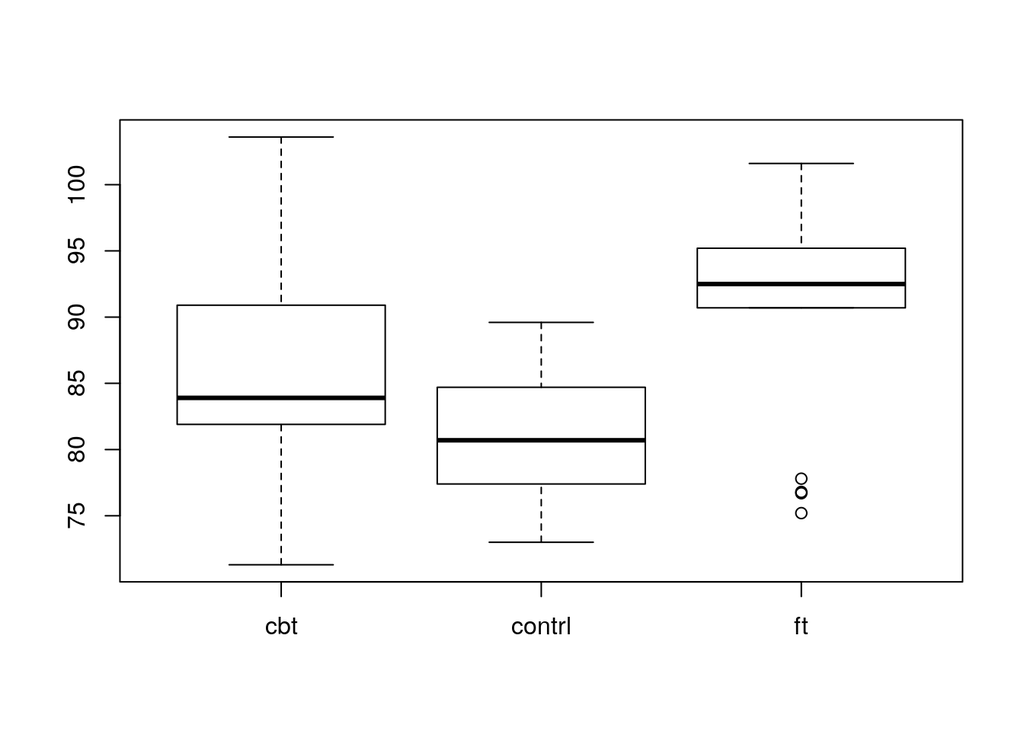

```r
boxplot(weight2 ~ treat, data = dat)
```

# Regression

## re-order factor levels

```r
dat$treat <- relevel(dat$treat, "contrl")
contrasts(dat$treat)
```

```
##        cbt ft
## contrl   0  0
## cbt      1  0
## ft       0  1
```

## Use lm for regression

```r
m1 <- lm(weight2 ~ weight1 + treat, data = dat)
summary(m1)
```

```
##
## Call:
## lm(formula = weight2 ~ weight1 + treat, data = dat)
##
## Residuals:
##      Min       1Q   Median       3Q      Max
## -14.1083  -4.2773  -0.5484   5.4838  15.2922
##
## Coefficients:
##             Estimate Std. Error t value Pr(>|t|)
## (Intercept)  45.6740    13.2167   3.456 0.000950 ***
## weight1       0.4345     0.1612   2.695 0.008850 **
## treatcbt      4.0971     1.8935   2.164 0.033999 *
## treatft       8.6601     2.1931   3.949 0.000189 ***
## ---
## Signif. codes:  0 '***' 0.001 '**' 0.01 '*' 0.05 '.' 0.1 ' ' 1
##
## Residual standard error: 6.978 on 68 degrees of freedom
## Multiple R-squared:  0.2777, Adjusted R-squared:  0.2458
## F-statistic: 8.713 on 3 and 68 DF,  p-value: 5.719e-05
```

## rockchalk::predictOMatic

```r
library(rockchalk)
predictOMatic(m1, predVals = c("weight1", "treat"))
```

```
##    weight1  treat      fit
## 1     70.0    cbt 80.18339
## 2     79.6    cbt 84.35422
## 3     82.3    cbt 85.52726
## 4     86.0    cbt 87.13477
## 5     94.9    cbt 91.00147
## 6     70.0 contrl 76.08632
## 7     79.6 contrl 80.25715
## 8     82.3 contrl 81.43020
## 9     86.0 contrl 83.03770
## 10    94.9 contrl 86.90441
## 11    70.0     ft 84.74645
## 12    79.6     ft 88.91728
## 13    82.3     ft 90.09032
## 14    86.0     ft 91.69783
## 15    94.9     ft 95.56454
```

## plotSlopes

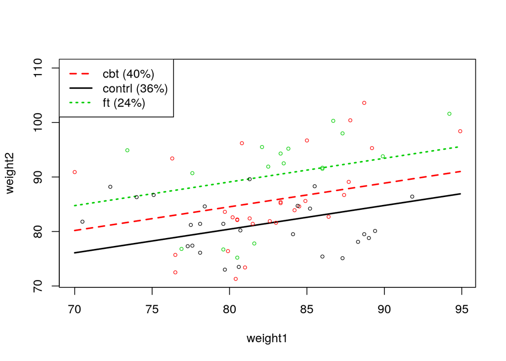

```r
plotSlopes(m1, plotx = "weight1", modx = "treat")
```

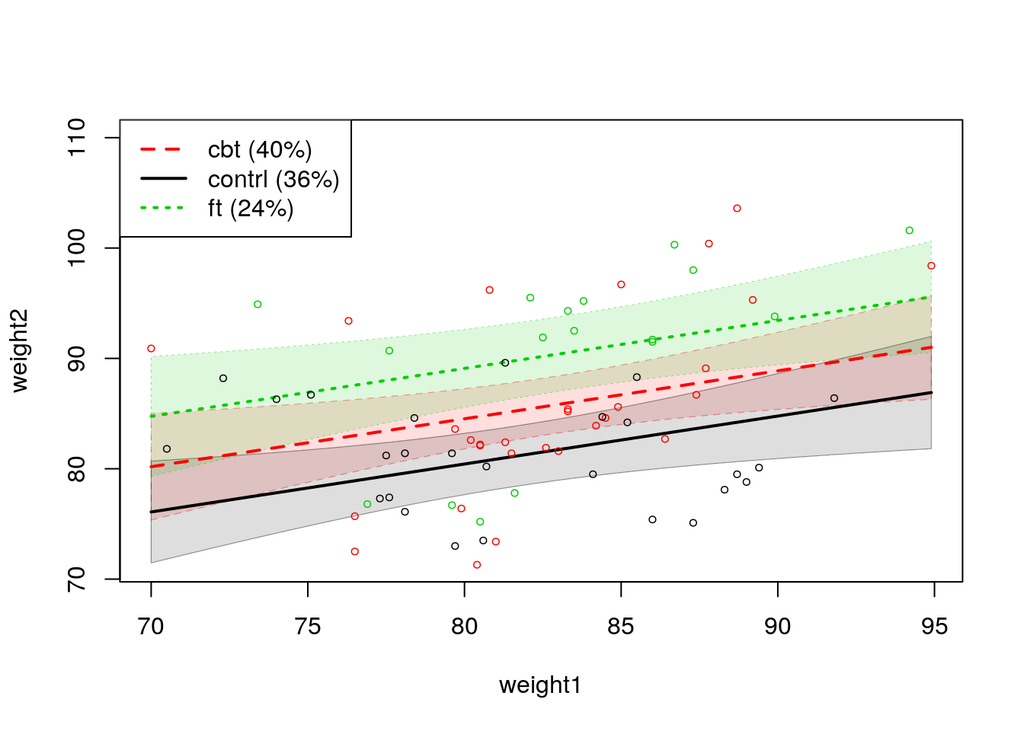

```r
plotSlopes(m1, plotx = "weight1", modx = "treat", interval = "confidence")
```

## T test for difference between coefficients.

```r
##' T-test for the difference in 2 regression parameters
##'
##' This is the one the students call the "fancy t test".
##'
##' I did this because I have trouble understanding terminology
##' in canned functions in other R packages
##' @param parm1 A parameter name, in quotes!
##' @param parm2 Another parameter name, in quotes!
##' @param model A fitted regression model
##' @return A list with the difference, std. err., t-stat,
##' and p value
##' @author Paul Johnson
fancyt <- function(parm1, parm2, model, model.cov = NULL){
    V <- function(mat, parm1, parm2 = NULL) {
        if(is.null(parm2)) return (mat[parm1, parm1])
        else return(mat[parm1, parm2])
    }
    if(is.null(model.cov)) model.cov <- vcov(model)

    model.coef <- coef(model)[c(parm1, parm2)]
    se <- sqrt(V(model.cov, parm1) + V(model.cov, parm2) - 2*V(model.cov, parm1, parm2))
    diff <- model.coef %*% c(1, -1)
    t <-  diff/se
    pval <- pt(abs(t), lower.tail = FALSE, df = model$df) * 2
    c(diff = diff, Std.Err. = se, t = t, p = pval)
}
```

```r
fancyt("treatcbt", "treatft", m1)
```

```
##        diff    Std.Err.           t           p
## -4.56306316  2.13333588 -2.13893331  0.03603506
```

## Regression diagnostics

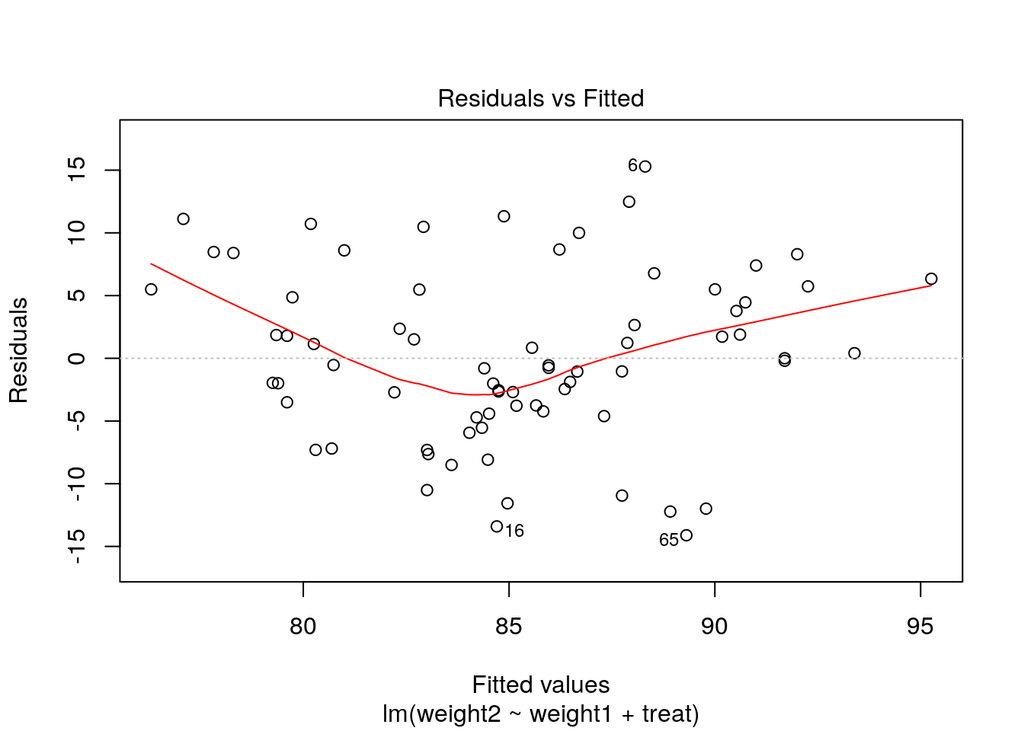

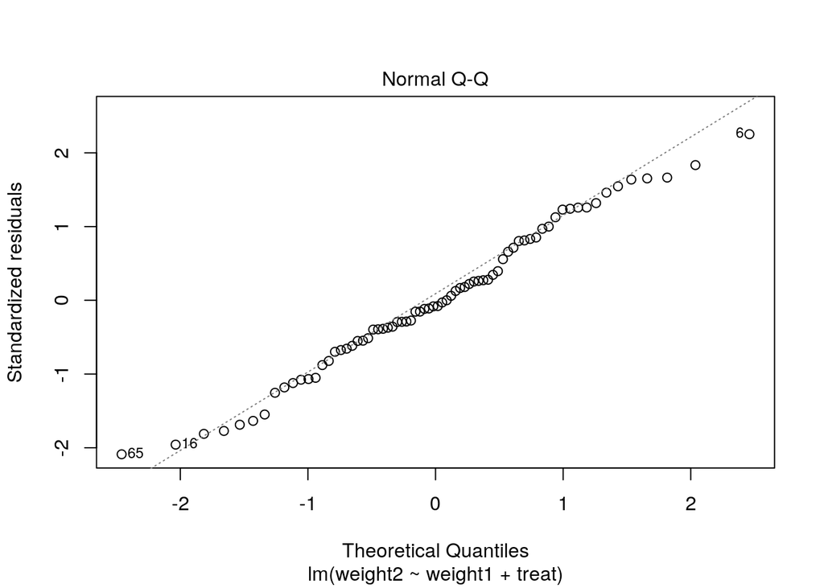

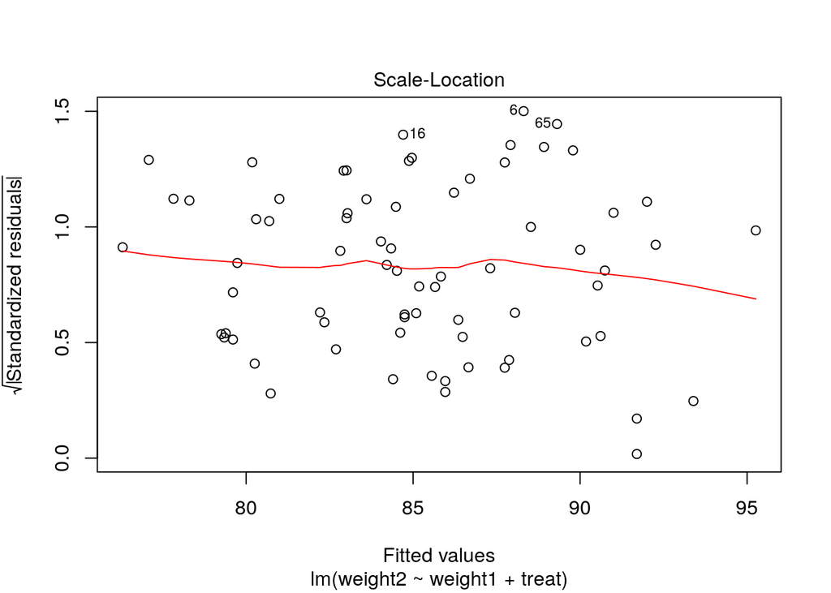

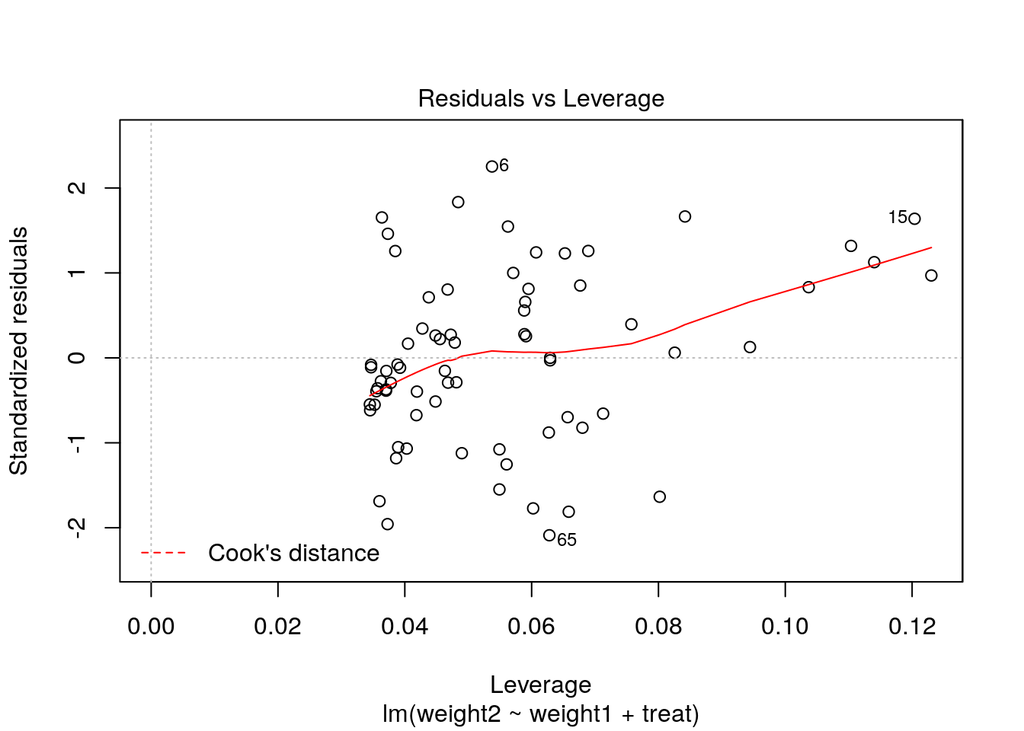

```r
plot(m1)
```

## Compare Robust Standard Errors

```r
## Exercise asks about homoskedasticity, do robust standard errors
library(sandwich)
## To match stata, we need type HC1
m1.robust <- vcovHC(m1, type = "HC1")
## StdError
m1.robust.se <- sqrt(diag(m1.robust))
m1.robust.se
```

```
## (Intercept)     weight1    treatcbt     treatft
##  15.0092502   0.1817614   1.8150058   2.1974315
```

```r
## Can compare to HC2 and HC3 in Stata, which are same:
sqrt(diag(vcovHC(m1, type = "HC2")))
```

```
## (Intercept)     weight1    treatcbt     treatft
##  15.2444507   0.1846019   1.8157956   2.2131725
```

```r
sqrt(diag(vcovHC(m1, type = "HC3")))
```

```
## (Intercept)     weight1    treatcbt     treatft
##   15.939738    0.193015    1.869854    2.294118
```

## Fancy t test using the robust standard errors

```r
fancyt("treatcbt", "treatft", m1, m1.robust)
```

```
##        diff    Std.Err.           t           p
## -4.56306316  2.32290159 -1.96438075  0.05357445
```

## Reasonable table, reasonably easy

```r
o1 <- outreg(list("m1 homo" = m1, "m1 robust" = m1 ),
       SElist = list("m1 robust" = m1.robust.se),
       type = "html", browse = FALSE)
```

```r
##markdown can't render HTML correctly
o1 <- gsub("[ ]{2,}", " ", o1)
cat(o1)
```

m1 homo

m1 robust

Estimate

Estimate

(S.E.)

(S.E.)

(Intercept)

45.674***

45.674**

(13.217)

(15.009)

weight1

0.434**

0.434*

( 0.161)

( 0.182)

treatcbt

4.097*

4.097*

( 1.893)

( 1.815)

treatft

8.660***

8.660***

( 2.193)

( 2.197)

N

72

72

RMSE

6.978

6.978

R<sup>2</sup>

0.278

0.278

adj R<sup>2</sup>

0.246

0.246

- p ≤0.05** p ≤0.01*** p ≤0.001

## Inspect residuals

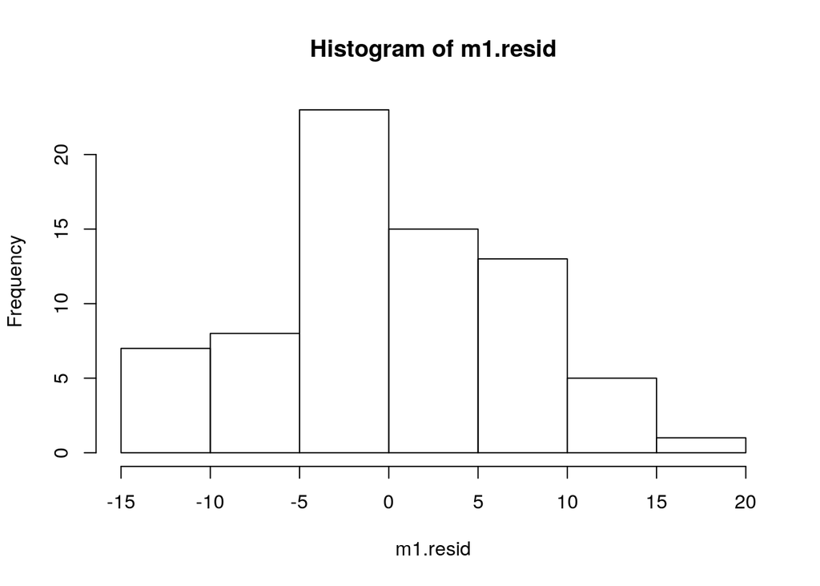

```r
m1.resid <- resid(m1)
hist(m1.resid)
```

```r
##' Histogram with added Kernel Density Smooth and Normal Probability
##'
##' See the working example at
##' http://pj.freefaculty.org/guides/Rcourse/WorkingExamples/
##' plot-histogramWithLinesAndLegend.html.. content for \details{} ..
##' @param x A variable to be plotted
##' @param main Title for graph
##' @return none
##' @author Paul Johnson
drawHist <- function(x, main = "Histogram"){
    xlab <- deparse(substitute(x))
    par(mai=c(1,1,2.5,1)) ## margins
    par(xpd=TRUE) ## write outside plot region

    myhist <- hist(x, prob = TRUE, main=main, xlab = xlab)
    lines(density(x))
    xseq1 <- seq(min(x), max(x), length.out=100)
    m1 <- mean(x)
    sd1 <- sd(x)
    obsNormal <- dnorm(xseq1, mean=m1, sd=sd1)
    lines(xseq1, obsNormal, lty=2, col="red")
    usr <- par("usr")
    legend(0.5 * usr[1] + 0.5 * usr[2], 1.3*usr[4],
           legend=c("observed density", "normal with observed mean & sd"),
           lty=c(1,2), col=c("black", "red"))
}
```

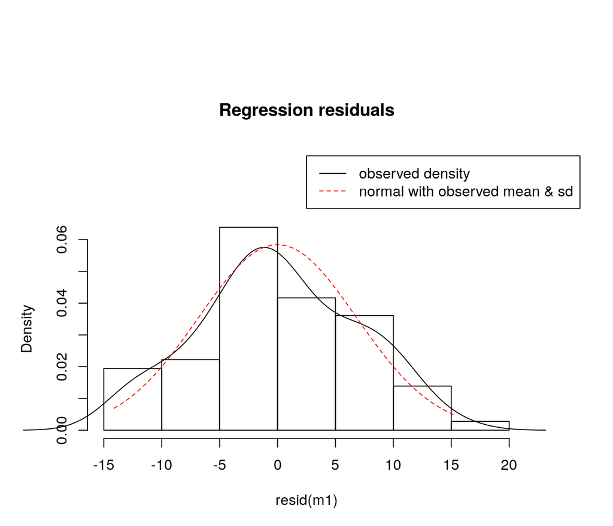

```r
drawHist(resid(m1), main = "Regression residuals")
```

# Add an interaction

## Regression formula: insert *

If you run predictors “x1 * x2”, then R will estimate coefficients for “x1”, “x2”, and the product, which R lables as “x1:x2”

```r
m3 <- lm(weight2 ~ weight1 * treat, data = dat)
summary(m3)
```

```
##
## Call:
## lm(formula = weight2 ~ weight1 * treat, data = dat)
##
## Residuals:
##      Min       1Q   Median       3Q      Max
## -12.8125  -3.8501  -0.9153   4.0010  15.9640
##
## Coefficients:
##                  Estimate Std. Error t value Pr(>|t|)
## (Intercept)       92.0515    18.8085   4.894 6.67e-06 ***
## weight1           -0.1342     0.2301  -0.583  0.56173
## treatcbt         -76.4742    28.3470  -2.698  0.00885 **
## treatft          -77.2317    33.1328  -2.331  0.02282 *
## weight1:treatcbt   0.9822     0.3442   2.853  0.00578 **
## weight1:treatft    1.0434     0.4000   2.609  0.01123 *
## ---
## Signif. codes:  0 '***' 0.001 '**' 0.01 '*' 0.05 '.' 0.1 ' ' 1
##
## Residual standard error: 6.565 on 66 degrees of freedom
## Multiple R-squared:  0.3794, Adjusted R-squared:  0.3324
## F-statistic:  8.07 on 5 and 66 DF,  p-value: 5.5e-06
```

## Plot the model with interaction

Interaction causes the slope for the effect of “weight1” to differ for each treatment group

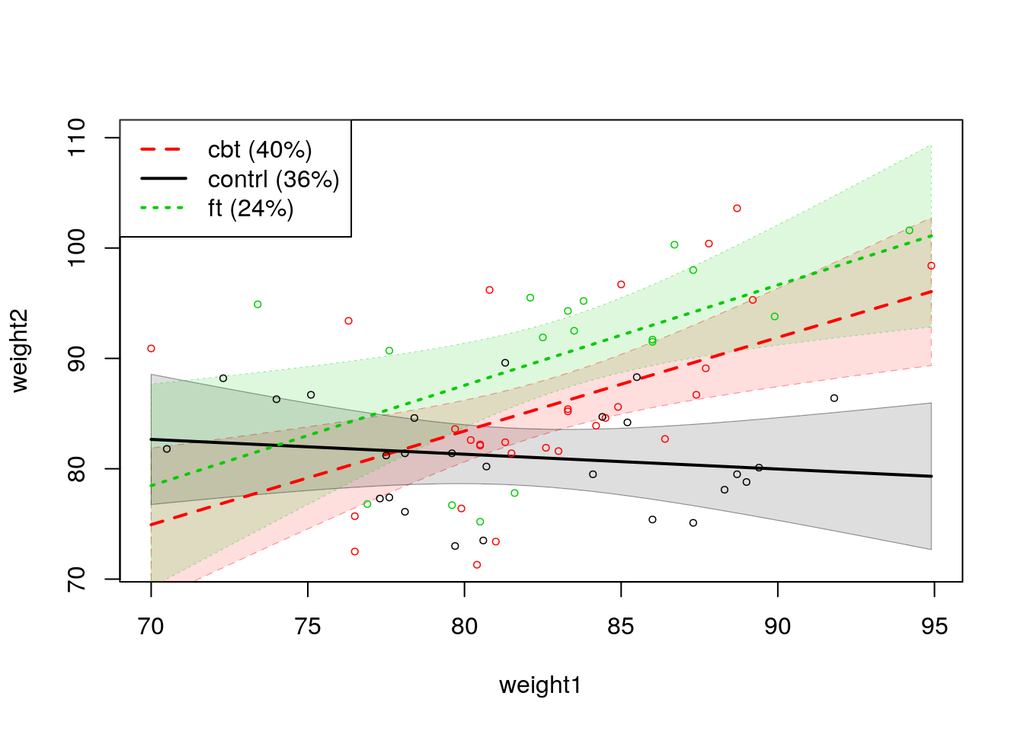

```r
m3.ps <- plotSlopes(m3, plotx = "weight1", modx = "treat", interval = "confidence")
```

```r
m3.ps.ts <- testSlopes(m3.ps)
```

```
## These are the straight-line "simple slopes" of the variable weight1
##  for the selected moderator values.
##                 "treat"      slope Std. Error    t value    Pr(>|t|)
## contrl          weight1 -0.1341844  0.2300754 -0.5832192 0.561733381
## cbt    weight1:treatcbt  0.8479817  0.2560564  3.3116992 0.001506729
## ft      weight1:treatft  0.9092264  0.3271713  2.7790528 0.007093750
```

## Compare robust standard errors

Get the robust standard errors

```r
m3.robust <- vcovHC(m3)
m3.robust.se <- sqrt(diag(sandwich(m3)))
```

```r
o3 <- outreg(list("m3 homo" = m3, "m3 robust" = m3 ),
       SElist = list("m3 robust" = m3.robust.se),
       type = "html")
```

```r
## markdown error correction:
o3 <- gsub("[ ]{2,}", " ", o3)
cat(o3)
```

m3 homo

m3 robust

Estimate

Estimate

(S.E.)

(S.E.)

(Intercept)

92.051***

92.051***

(18.809)

(11.864)

weight1

-0.134

-0.134

( 0.230)

( 0.145)

treatcbt

-76.474**

-76.474*

(28.347)

(34.679)

treatft

-77.232*

-77.232*

(33.133)

(35.866)

weight1:treatcbt

0.982**

0.982*

( 0.344)

( 0.414)

weight1:treatft

1.043*

1.043*

( 0.400)

( 0.418)

N

72

72

RMSE

6.565

6.565

R<sup>2</sup>

0.379

0.379

adj R<sup>2</sup>

0.332

0.332

- p ≤0.05** p ≤0.01*** p ≤0.001

## Conduct some fancy t tests

```r
fancyt("treatcbt", "treatft", m3, m3.robust)
```

```
##        diff    Std.Err.           t           p
##  0.75749810 61.92740658  0.01223203  0.99027739
```

```r
fancyt("weight1:treatcbt", "weight1:treatft", m3)
```

```
##        diff    Std.Err.           t           p
## -0.06124471  0.41545871 -0.14741467  0.88325414
```

```r
fancyt("weight1:treatcbt", "weight1:treatft", m3, m3.robust)
```

```
##        diff    Std.Err.           t           p
## -0.06124471  0.72739257 -0.08419760  0.93315420
```

## Inspect residuals

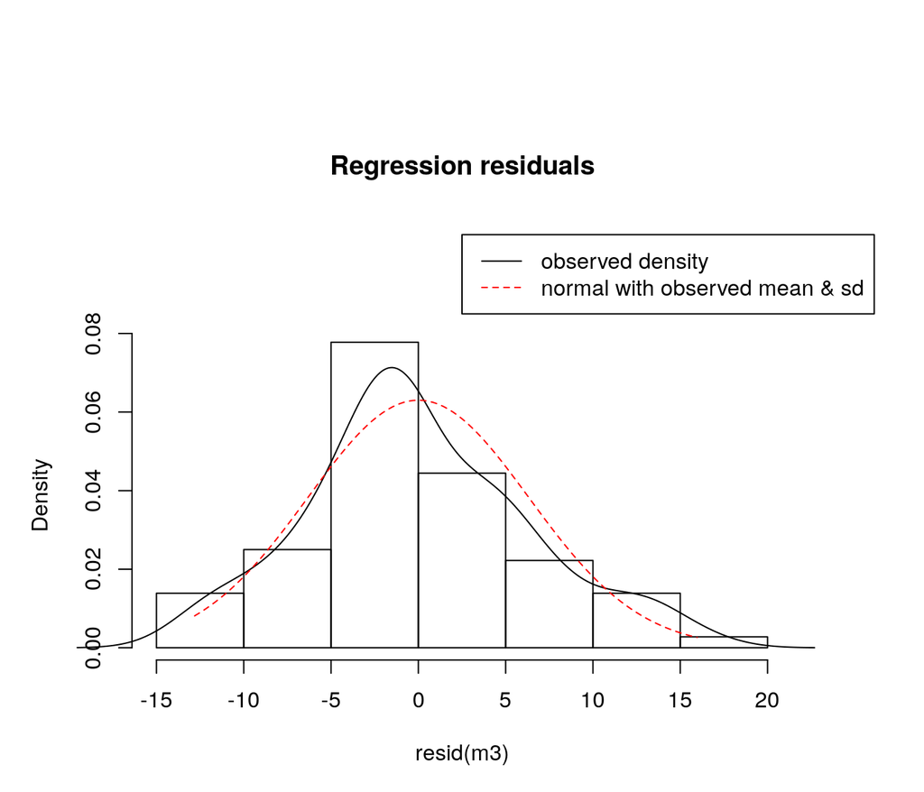

```r
drawHist(resid(m3), main = "Regression residuals")
```

## Standard regression diagnostics

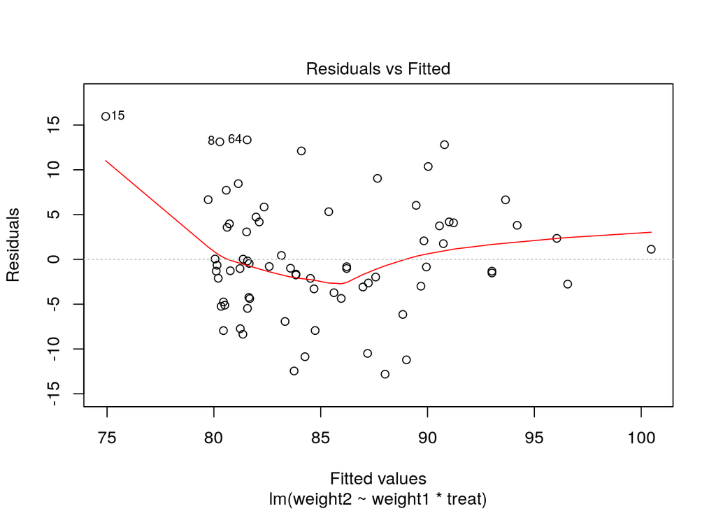

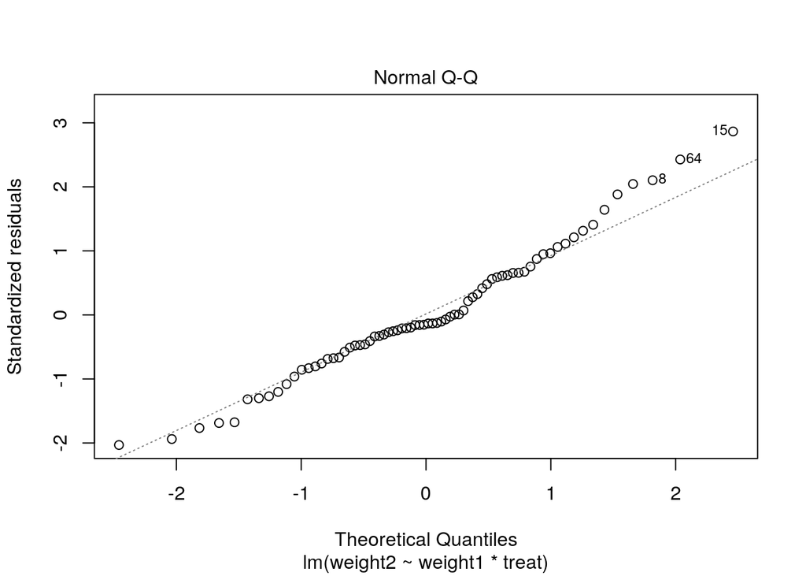

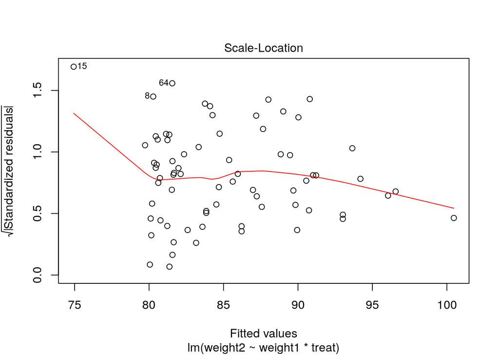

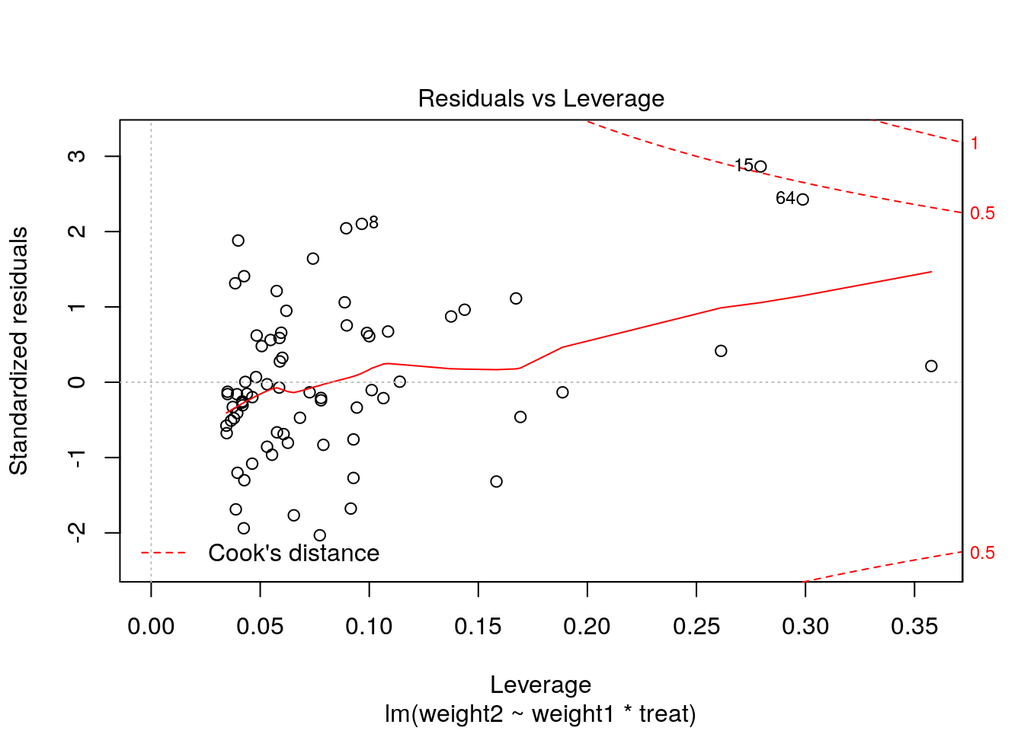

```r
plot(m3)
```

# Followup: are cbt and ft interchangeable?

## I’d consider combining the groups “cbt” and “ft”

```r
dat$treat2 <- combineLevels(dat$treat, c("cbt", "ft"), newLabel = "cbtorft")
```

```
## The original levels contrl cbt ft
## have been replaced by contrl cbtorft
```

```r
m4 <- lm(weight2 ~ weight1 * treat2, data = dat)
summary(m4)
```

```
##
## Call:
## lm(formula = weight2 ~ weight1 * treat2, data = dat)
##
## Residuals:
##      Min       1Q   Median       3Q      Max
## -13.9423  -4.8110  -0.9037   4.7390  15.9212
##
## Coefficients:
##                       Estimate Std. Error t value Pr(>|t|)
## (Intercept)            92.0515    19.1734   4.801 9.03e-06 ***
## weight1                -0.1342     0.2345  -0.572  0.56913
## treat2cbtorft         -78.7503    25.6524  -3.070  0.00308 **
## weight1:treat2cbtorft   1.0290     0.3117   3.302  0.00153 **
## ---
## Signif. codes:  0 '***' 0.001 '**' 0.01 '*' 0.05 '.' 0.1 ' ' 1
##
## Residual standard error: 6.693 on 68 degrees of freedom
## Multiple R-squared:  0.3356, Adjusted R-squared:  0.3062
## F-statistic: 11.45 on 3 and 68 DF,  p-value: 3.64e-06
```

Conduct an F test to find out if m3 is preferred to m4

```r
anova(m3, m4)
```

```
## Analysis of Variance Table
##
## Model 1: weight2 ~ weight1 * treat
## Model 2: weight2 ~ weight1 * treat2
##   Res.Df    RSS Df Sum of Sq      F Pr(>F)
## 1     66 2844.8
## 2     68 3045.8 -2   -201.04 2.3321  0.105
```

These *are* nested models.

What did we find out? The original model, m3, had predictive formula:

$$\widehat{weight2}_i = 92.05 - 0.13weight1_i - 76.47 cbt - 77.23 ft + 0.98 weight1_i \cdot cbt_i + weight1_i\cdot ft_i$$

The `anova` test is not statistically significant, meaning the second model is not “worse” than the first. The usual choice, then, is to keep the simpler model.

A counter-argument might be that the funding agency requires us to separately estimate the effect of the 2 treatments, so we might we well advised to make a table that includes both models. Iti s a little tricky to arrange that table with proper labels, however.